# Postawa wobec statystyki

Tomasz Przechlewski

Powiślańska Szkoła Wyższa (Kwidzyn/Poland)  
t.plata-przechlewski@psw.kwidzyn.edu.pl

Listopad 2023

## Uwagi ogólne

Analiza odpowiedzi na ankietę mierzącą Postawę względem Statystyki (PwS) wypełnione do 4/11/2023.

Postawę zmierzono za pomocą 28 pytań, które mierzą cztery różne aspekty postawy: afekt, kompetencje poznawcz, wartość i trudność. Mierzymy pozytywną postawę stąd pytania 2, 3, 5, 6, 9–12, 14, 16, 18–22 oraz 25–28 są mierzone za pomocą skali odwróconej:

**Afekt**

1. Polubię statystykę
2. Będę się czuł niepewnie gdy będę musiał rozwiązywać zadania statystyczne. (r)
3. Podczas kolokwiów ze statystyki będę sfrustrowany (r)
4. Będę zestresowany na zajęciach ze statystyki (r)
5. Chętnie wezmę udział w zajęciach ze statystyki
6. Statystyka mnie przeraża (r)

**Kompetencje poznawcze**

3. Mój sposób myślenia powoduje że mam kłopoty ze zrozumieniem statystyki (r)
4. Nie mam pojęcia o co chodzi w statystyce (r)
5. Zajmując się statystyką popełniam wiele błędów matematycznych (r)
6. Mogę nauczyć się statystyki
7. Zrozumiem wzory statystyczne
8. Zrozumienie pojęć ze statystyki będzie dla mnie trudne (r)

**Wartość**

5. Statystyka jest bezwartościowa (r)
6. Statystyka powinna być obowiązkowym przedmiotem na studiach
7. Znajomość statystyki ułatwi mi znalezienie pracy
8. Profesjonalista nie potrzebuje znajomości statystyki (r)
9. Za wyjątkiem wykorzystania w pracy zawodowej statystyka jest bezużyteczna (r)
10. Wykorzystuję statystykę w codziennym życiu
11. Na co dzień rzadko się widzi wykorzystanie statystyki (r)
12. Statystyka nie przyda się w moim zawodzie (r)
13. Statystyka nie ma żadnego znaczenia w moim życiu (r)

**Trudność** (a w zasadzie **Łatwość**)

4. Wzory statystyczne są łatwe do zrozumienia
5. Statystyka jest skomplikowana (r)
6. Większość ludzi szybko uczy się statystyki
7. Nauczenie się statystyki wymaga dużej dyscypliny (r)
8. Statystyka wymaga żmudnych obliczeń (r)
9. Statystyka jest wysoce specjalistyczna (r)
10. Większość ludzi musi nauczyć się nowego sposobu myślenia aby zajmować się statystyką (r)

Jeżeli osoba uważa statystykę za superłatwą to wartość PwS wyniesie 196; jeżeli osoba uważa statystykę za supertrudną to PwS=28.

## Metryczka

Łącznie otrzymano 451 ankiet.

### Płeć respondentów

| płeć | n | % |
| --- | --- | --- |
| K | 315 | 69.84479 |
| M | 136 | 30.15521 |

albo na wykresie

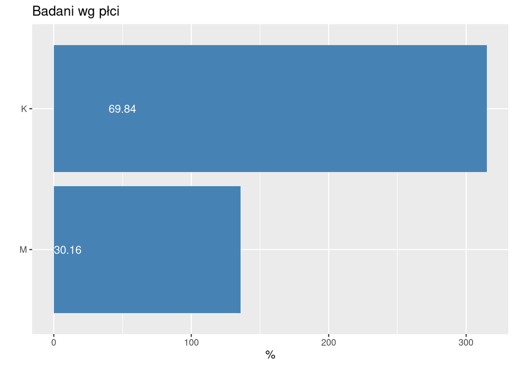

### Wiek

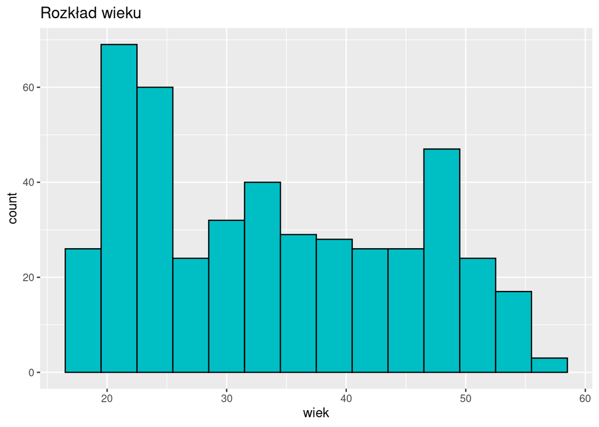

### Odległość od PSW

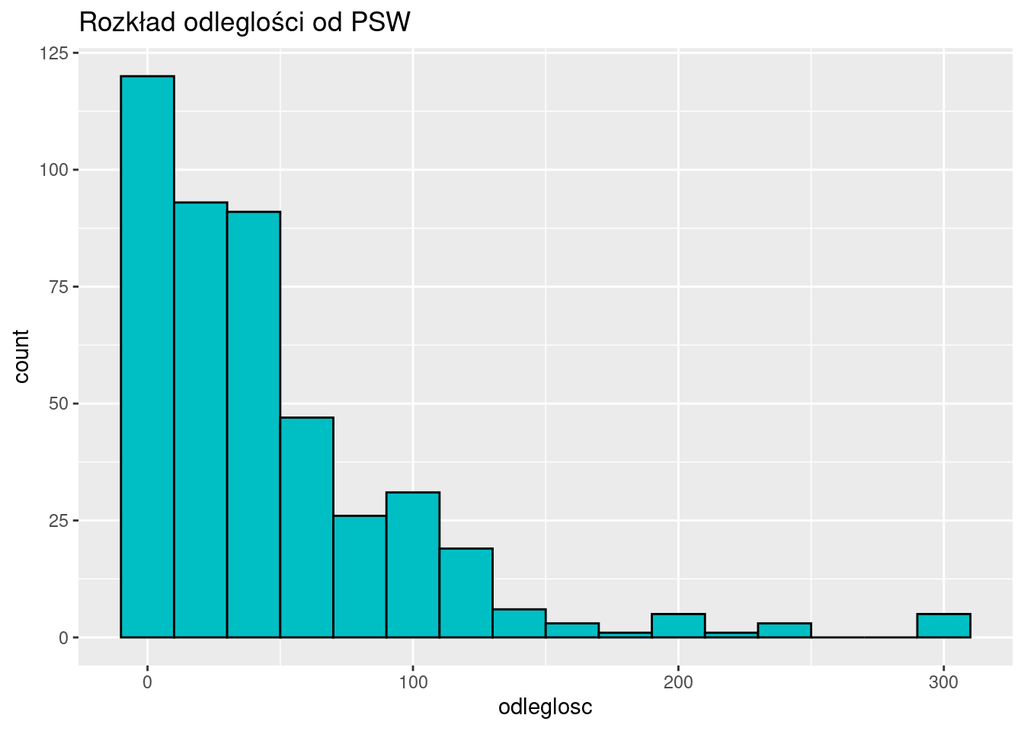

## Samoskuteczność

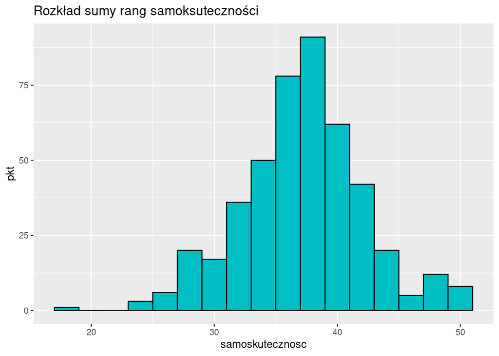

## Rozkład wartości zmiennej pn *Postawa wobec statystyki*

Średnia wartość PwS wyniosła 117.0266075 (co stanowi 59.7074528% wartości maksymalnej) Wartość maksymalna 189; wartość minimalna 51. Wartość mediany wyniosła 116.

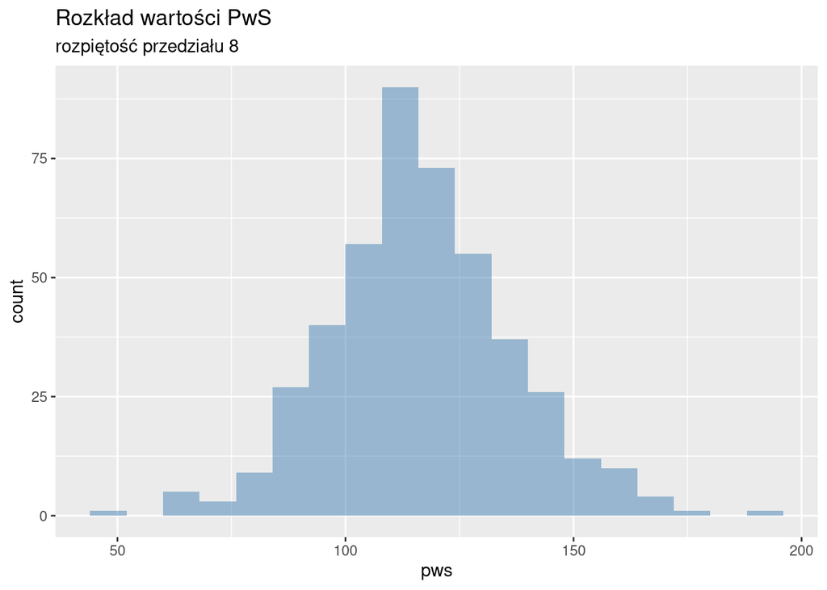

Wartości średnie (mediana), rozproszenie oraz wartości odstające (kropki) na wykresie (zwanym pudełkowym):

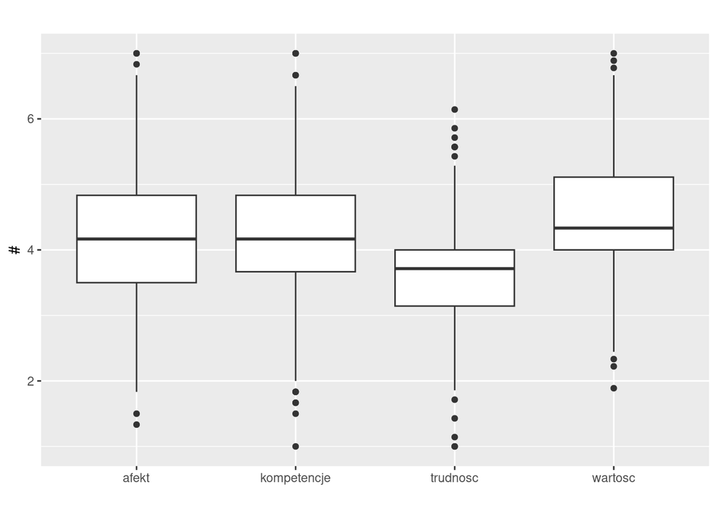

## Płeć a PwS

| sex | m | me | q1 | q3 | sd |
| --- | --- | --- | --- | --- | --- |
| K | 113.83 | 113 | 102.00 | 124.00 | 18.07 |
| M | 124.43 | 124 | 111.75 | 139.25 | 22.08 |

albo na wykresie

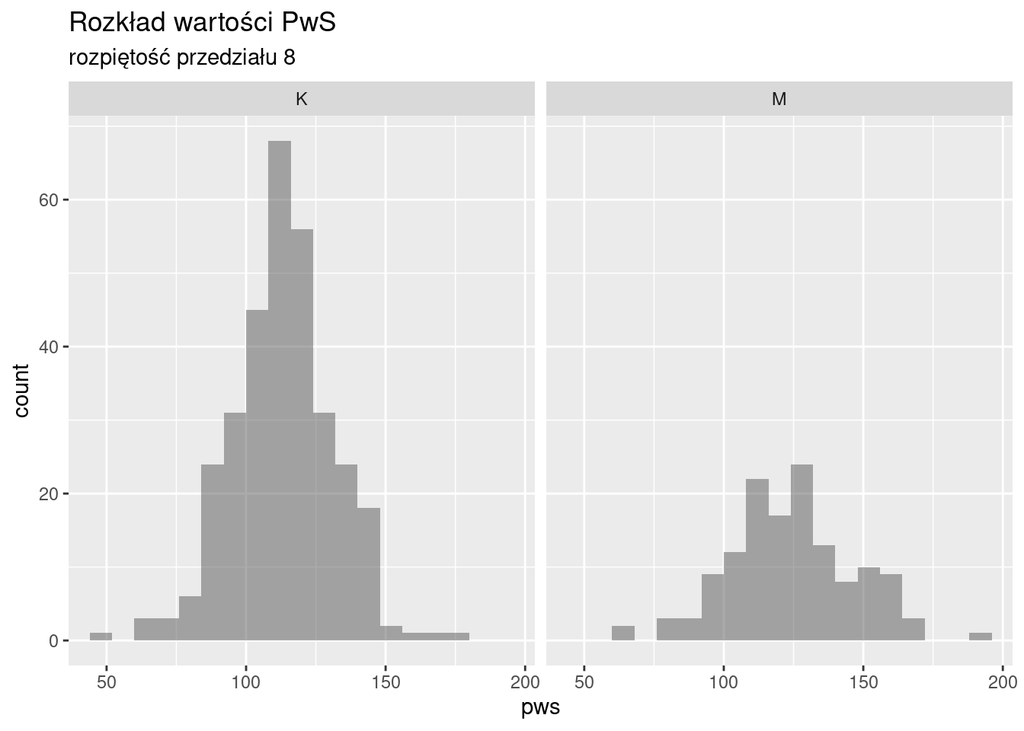

Średnie wartości poszczególnych wymiarów (min = 1; max = 7):

- afekt (nie lubię–lubię): 4.1910569,

| sex | m |
| --- | --- |
| K | 4.047619 |
| M | 4.523284 |

- kompetencje (nie mam–mam): 4.2971175,

| sex | m |
| --- | --- |
| K | 4.138095 |
| M | 4.665441 |

- wartość (nie przyda mi się–przyda mi się): 4.4981523,

| sex | m |
| --- | --- |
| K | 4.431746 |
| M | 4.651961 |

- łatwość (trudna–łatwa) 3.6591701;

| sex | m |
| --- | --- |
| K | 3.547392 |
| M | 3.918067 |

## Wiek a PwS

```
##
## Call:
## lm(formula = pws ~ wiek, data = d1)
##
## Residuals:
##     Min      1Q  Median      3Q     Max
## -64.715 -12.855  -1.289  11.938  71.365
##
## Coefficients:
##              Estimate Std. Error t value            Pr(>|t|)
## (Intercept) 124.24892    2.99756  41.450 <0.0000000000000002 ***
## wiek         -0.21334    0.08414  -2.535              0.0116 *
## ---
## Signif. codes:  0 '***' 0.001 '**' 0.01 '*' 0.05 '.' 0.1 ' ' 1
##
## Residual standard error: 19.83 on 449 degrees of freedom
## Multiple R-squared:  0.01412,    Adjusted R-squared:  0.01192
## F-statistic: 6.429 on 1 and 449 DF,  p-value: 0.01157
```

## Kierunek a PwS

| kierunek | średni pws |
| --- | --- |
| Pielęgniarstwo | 113.7282 |
| Ratownictwo Medyczne | 122.7988 |

## Czy istnieje zależność między PwS oraz płcią?

Stosujemy test t Welcha. Hipotezą zerową (wstępnym założeniem) jest, że pomiędzy PsW i płcią nie ma zależności. Formalnie, że średnie wartości w obu grupach zmiennej `psw` są identyczne.

| Grupa1 | Grupa2 | n1 | n2 | t | p |
| --- | --- | --- | --- | --- | --- |
| K | M | 315 | 136 | -4.929076 | 0.0000016 |

Hipotezę zerową należy odrzucić. Mężczyźni mają statystycznie istotne wyższe pozytywne nastawienie do statystyki.

Sprawdzamy założenia dotyczące normalności (test Shapiro-Wilka)

| płeć | S-W | p |
| --- | --- | --- |
| K | 0.9933662 | 0.1798830 |
| M | 0.9924679 | 0.6866553 |

Rozkłady są normalne. Wykorzystanie testu t Welcha było uzasadnione.

## Czy istnieje zależność pomiędzy `pws.trudnosc` a wiekiem?

$$psw.trudnosc = b_0 + b_1 \cdot
wiek$$

| Zmienna | B | SE | z | p | CI95 |
| --- | --- | --- | --- | --- | --- |
| (Intercept) | 28.416 | 0.774 | 36.694 | 0 | 26,89 29,94 |
| wiek | -0.083 | 0.022 | -3.807 | 0 | -0,13 -0,04 |

## Wiek a `psw.wartosc`

| Zmienna | B | SE | z | p | CI95 |
| --- | --- | --- | --- | --- | --- |
| (Intercept) | 40.992 | 1.170 | 35.043 | 0.000 | 38,69 43,29 |
| wiek | -0.015 | 0.033 | -0.458 | 0.647 | -0,08 0,05 |

nie ma zależności.

## pws a samoskutecznosc

```
##
## Call:
## lm(formula = pws ~ samoskutecznosc, data = d1)
##
## Residuals:
##     Min      1Q  Median      3Q     Max
## -59.722 -11.579  -0.674  11.385  58.136
##
## Coefficients:
##                 Estimate Std. Error t value             Pr(>|t|)
## (Intercept)      74.9139     6.8957   10.86 < 0.0000000000000002 ***
## samoskutecznosc   1.1190     0.1817    6.16        0.00000000162 ***
## ---
## Signif. codes:  0 '***' 0.001 '**' 0.01 '*' 0.05 '.' 0.1 ' ' 1
##
## Residual standard error: 19.17 on 449 degrees of freedom
## Multiple R-squared:  0.07793,    Adjusted R-squared:  0.07588
## F-statistic: 37.95 on 1 and 449 DF,  p-value: 0.000000001617
```

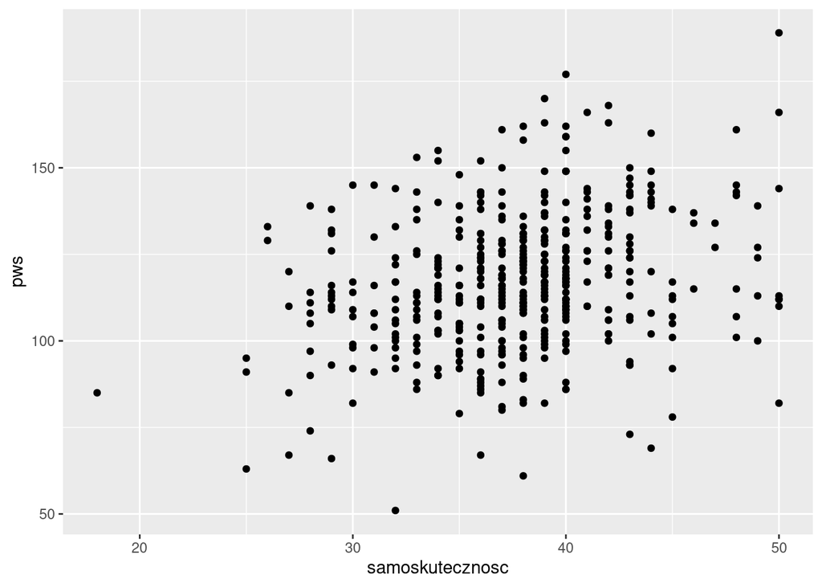

```
##
## Call:
## lm(formula = pws ~ samoskutecznosc + sex, data = d1)
##
## Residuals:
##     Min      1Q  Median      3Q     Max
## -57.583 -12.198   0.336  11.372  60.352
##
## Coefficients:
##                 Estimate Std. Error t value             Pr(>|t|)
## (Intercept)       76.322      6.744  11.317 < 0.0000000000000002 ***
## samoskutecznosc    1.008      0.179   5.631         0.0000000316 ***
## sexM               9.165      1.939   4.727         0.0000030576 ***
## ---
## Signif. codes:  0 '***' 0.001 '**' 0.01 '*' 0.05 '.' 0.1 ' ' 1
##
## Residual standard error: 18.73 on 448 degrees of freedom
## Multiple R-squared:  0.1217, Adjusted R-squared:  0.1178
## F-statistic: 31.05 on 2 and 448 DF,  p-value: 0.0000000000002358
```

## Literatura

Abraham Ayebo, Jered Bright, Christian Ballam, *Examining the Factor Structure of the Survey of Attitudes Towards Statistics among Undergraduate Health Science Students*, https://doi.org/10.29333/iejme/5942

Yuhai Zhang i inni, *Attitudes toward statistics in medical postgraduates: measuring, evaluating and monitoring*, http://www.biomedcentral.com/1472-6920/12/117

Norizan Anwar, Aniza Jamaluddin and Hanis Diyana Kamarudin, *Attitude of Students towards Statistics Application*, Global J. Bus. Soc. Sci. Review 1 (3) 78–83 (2013)